# Trabalho Computacional - Teoria da Decisão - UFMG

Pedro Loes

27/02/2021

## Resumo

- Este artigo apresenta uma solução para um problema aplicado do curso de *Teoria da Decisão* do departamento de *Engenharia de Sistemas* da **UFMG** ministrado pelo professor *Lucas Batista*. O objetivo deste trabalho foi aplicar as técnicas de otimização e teoria da decisão lecionadas ao longo do semestre. O desenvolvimento compreende a exploração de **mínimos locais** e **mínimos globais**. A conclusão visou otimizar o número de roteadores de pontos de acesso para suprir os consumos de banda demandados pelos clientes, atendendo à restrições pré-estabelecidas. Finalmente na etapa otimizador em produção foi criado um aplicativo para generalizar o uso do algoritimo em problemas semelhantes.

## Introdução

- O problema foi modelado no software **R** com implementação da função objetivo em **C++** .
- Diferentes espaços de busca foram considerados com o intuito de descobrir a partir de qual densidade de espaço de busca discretizado o algoritmo convergiria para a solução de mínimo global ótima.

## Especificações do Problema

- Deseja-se instalar uma rede **WLAN** do tipo **N 2D** para atendimento de um centro de convenções com **800 × 800 metros**. Para planejamento dessa rede foram estimados **500** pontos de demanda, com suas respectivas posições geográficas e consumos de largura de banda. O arquivo clientes.csv contém:
  - Coordenada **x** do cliente em metros.
  - Coordenada **y** do cliente em metros.
  - Consumo de banda do cliente em **Mbps**.
- Amostra das **10** primeiras observações:

| Id | x | y | Mbps |
| --- | --- | --- | --- |
| 1 | 168.99 | 220.62 | 0.47347 |
| 2 | 218.11 | 211.16 | 0.41026 |
| 3 | 207.48 | 157.38 | 1.37570 |
| 4 | 213.25 | 189.93 | 0.93025 |
| 5 | 199.19 | 140.71 | 0.15790 |
| 6 | 177.74 | 188.51 | 0.94899 |
| 7 | 197.44 | 176.30 | 0.30420 |
| 8 | 161.48 | 197.12 | 1.16990 |
| 9 | 189.84 | 211.32 | 1.29950 |
| 10 | 269.22 | 224.90 | 0.51370 |

- Variáveis de Decisão:
  - Coordenadas dos pontos a serem instalados na área de **800 x 800 metros**.
  - Ponto de Acesso que será responsável pelo atendimento de cada cliente.
- Restrições:
  - Ao menos **95%** dos pontos de demanda devem ter suas demandas integralmente atendidas.
  - Cada ponto de acesso a ser instalado tem capacidade de **150Mbps**, que não pode ser excedida.
  - Um cliente pode ser atendido por um **Pa** se a distância entre ambos é inferior a **85 metros**.
  - Cada cliente só pode ser atendido por um único **Pa**.
  - Devido a restrições orçamentárias, podem ser instalados no máximo **100 Pa’s**.
- Simplificações:
  - Os pontos de demanda e seus consumos de banda são estáticos.
  - O efeito de obstáculos no ambiente foram desprezados.
  - Um ponto de acesso não causa interferência em outros.

## Modelagem

- Definição de Variáveis:
  - $Pd_i \hspace{0.2cm} \leftarrow$ Pontos de Demanda $i = \{1, 2, 3, ..., 500\}$, $Pd_i \in$ $R\{x, y\}$, x, y = $\{1, ..., 800\}$
  - $Pa_j \hspace{0.16cm} \leftarrow$ Pontos de Acesso $j = \{1, 2, ..., 100\}$, $Pa_j \in$ $R\{x, y\}$, x, y = $\{1, ..., 800\}$
  - $\beta_i \hspace{0.43cm} \leftarrow$ Consumo de banda em Mbps dos Pd’s, $\forall \hspace{0.1cm} i \in Pd_i \hspace{0.1cm}$
  - $d_{i,j} \hspace{0.22cm} \leftarrow$ Distância Euclidiana entre $Pd_i$ e $Pa_j$, $\forall \hspace{0.1cm} i \in Pd_i \hspace{0.1cm}$, $\forall \hspace{0.1cm} j \in Pa_j$
  - $\alpha_j \hspace{0.38cm} \leftarrow$ Ativação do $Pa_j$, $\alpha_j$ $\in \{0,1\}$ $\forall \hspace{0.1cm} j \in Pa_j$
  - $\eta_{i,j} \hspace{0.24cm} \leftarrow$ Atendimento do $Pd_i$ pelo $Pa_j$, $\eta_{i,j}$ $\in \{0,1\}$ $\forall \hspace{0.1cm} i \in Pd_i \hspace{0.1cm}$, $\forall \hspace{0.1cm} j \in Pa_j$
- Definição da Função 1:
  - min $(\sum_{j=1}^{|P_a|} \hspace{0.1cm} \alpha_j)$
- Definição da Função 2:
  - min $( \sum_{i=1}^{|P_d|} \hspace{0.1cm} \sum_{j=1}^{|P_a|} \hspace{0.1cm} d_{i,j} \hspace{0.1cm} \times \hspace{0.1cm} \eta_{i,j})$
- Definição das Restrições:
  - $\sum_{i=1}^{|P_d|}\hspace{0.1cm} \sum_{j=1}^{|P_a|} \hspace{0.1cm} \eta_{i,j} \hspace{0.1cm} \geq \hspace{0.1cm} 475$
  - $\sum_{i=1}^{|P_d|} \hspace{0.1cm} \eta_{i,j} \hspace{0.1cm} \times \hspace{0.1cm} \beta_i \hspace{0.1cm} \le \hspace{0.1cm} 150 \hspace{0.3cm} \forall \hspace{0.1cm} j \in \alpha_j=1$
  - $\sum_{j=1}^{|Pa|} \hspace{0.1cm} \eta_{i,j} \hspace{0.1cm} \le \hspace{0.1cm} 1 \hspace{0.3cm} \forall \hspace{0.1cm} i \in Pd$
  - $\sum_{j=1}^{|Pa|} \hspace{0.1cm} \alpha_j \hspace{0.1cm} \le \hspace{0.1cm} 100$
  - $\exists \hspace{0.1cm} \eta_{i,j} \hspace{0.1cm} \forall \hspace{0.1cm} d_{i,j} \hspace{0.1cm} \le \hspace{0.1cm} 85$

## Análise Exploratória

- Para ilustrar uma visão inicial da distribuição dos clientes no espaço de 800 x 800 foi elaborado um gráfico de dispersão 2d com os dados da localização **(x, y)** dos pontos de demanda.
- O parâmetro **alpha** de transparência foi alterado para **0.5** com o intuito de eliminar o problema da sobreposição de **Pd’s** e facilitar a compreensão da densidade destes pontos.
- A dimensão de cor foi adicionada considerando o gradiente das cores preta até azul para o consumo de largura de banda requisitada em **Mbps** por cada cliente.

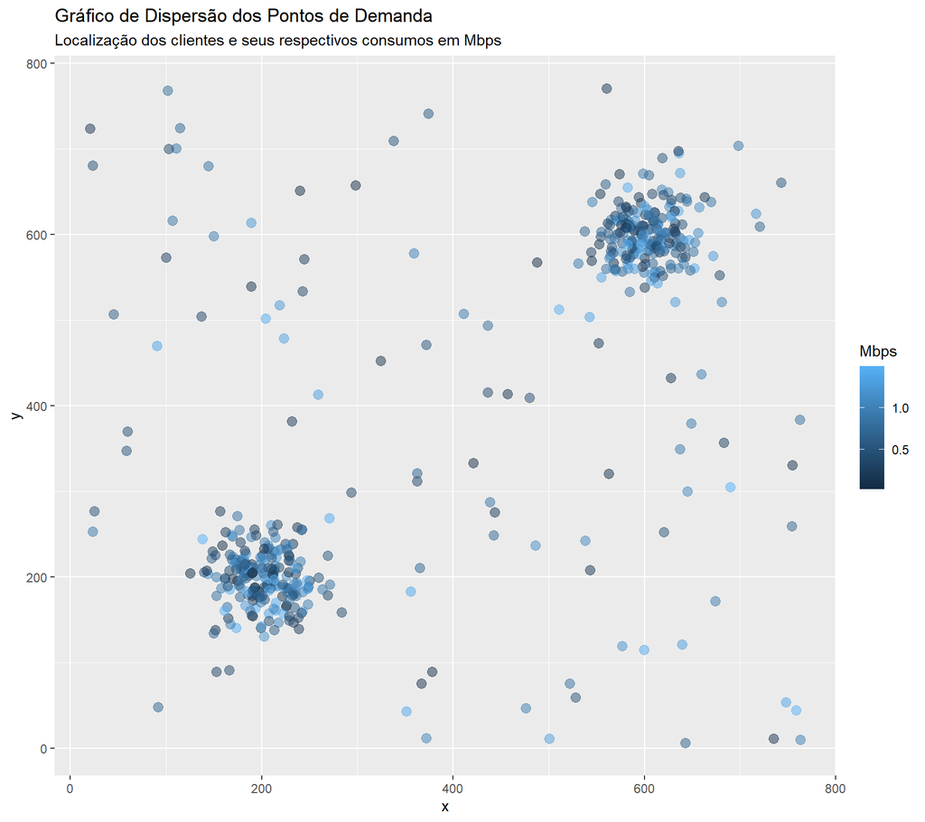

- Existem **2** grandes clusters na dispersão da localização dos clientes em torno dos pontos **(200, 200)** e **(600, 600)**. Os demais pontos apresentam distribuição esparsa na área de **800 x 800** metros.
- Na diagonal que vai de **(0,0)** até **(800,800)** os pontos de demanda são menos espalhados mas na diagonal **(0,800)** até **(800,0)** os pontos estão mais dispersos.
- Parece não existir padrão visual para a distribuição das demandas de banda em **Mbps**.

## Espaços de Busca

- Se considerada uma escala continua, a área de **800 x 800** metros possuí infinitas coordenadas de possíveis localizações para os pontos de acesso.
- A construção de espaços de busca considerou espaços discretizados na forma de matrizes do tipo $\boldsymbol M_{ \boldsymbol ( \boldsymbol i, \boldsymbol j \boldsymbol )}$ com **i = {8, 9, …, 150}** e **j = {8, 9, …, 150}**. A posição **i** representa a quantidade de posições igualmente espaçadas no eixo **x** e da mesma forma, a posição **j** no eixo **y**.

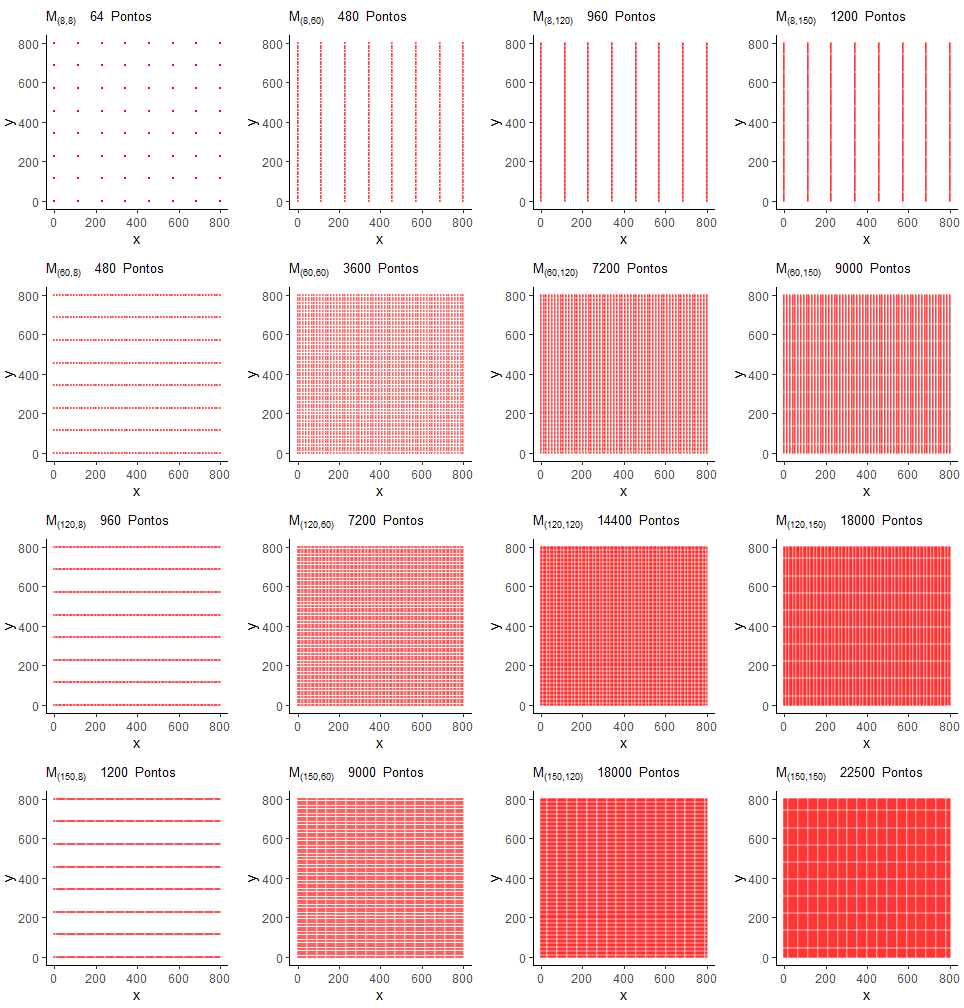

- O **1º** gráfico no canto **superior esquerdo** ilustra a área discreta de **800 x 800** em **8** posições igualmente espaçadas para o eixo **x** e **y** totalizando **64** possíveis localizações para os pontos de acesso.
- Os gráficos fora da diagonal principal ilustram alguns dos espaços discretos irregulares arbitrariamente escolhidos, ou seja, o número de posições diferente para os eixos **x** e **y**.
- O último gráfico no canto inferior direito ilustra a área discreta de **800 x 800** em **150** posições igualmente espaçadas para o eixo **x** e **y** totalizando **22500** possíveis localizações para os pontos de acesso.